# Module-9

# The Central Limit Theorem

```r
lambda <- 14
n <- 10
pop_se <- sqrt(lambda/n)  # the estimated SE
pop_se
```

```
## [1] 1.183216
```

this is the populaiton se

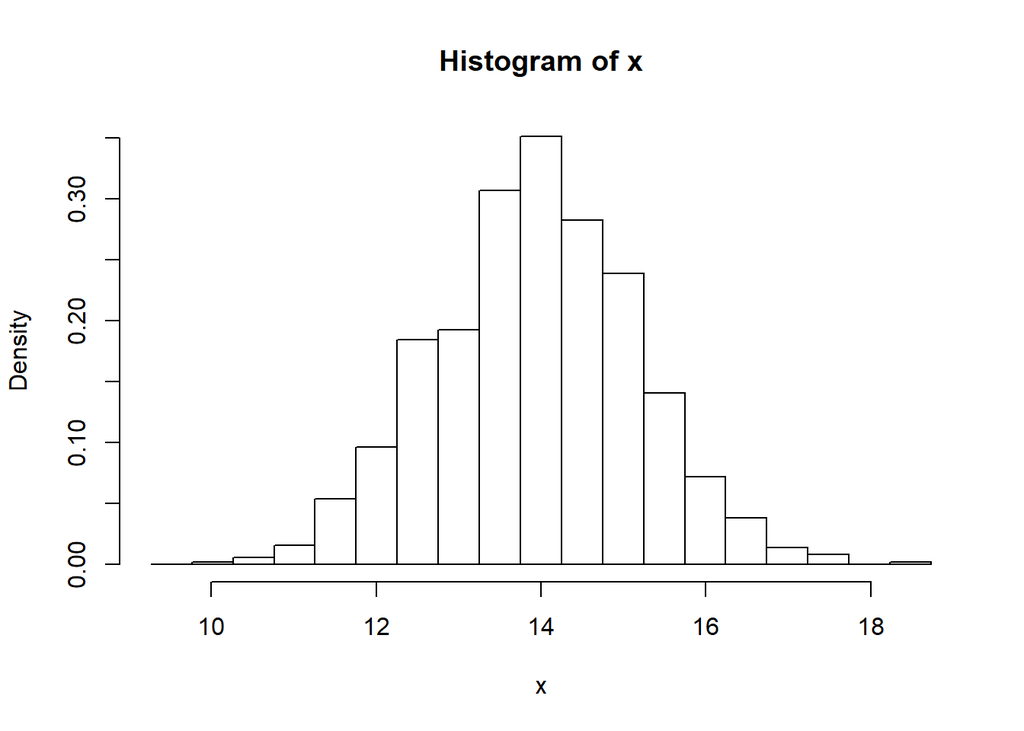

```r
x <- NULL
for (i in 1:1000) {
    x[i] <- mean(rpois(n = n, lambda = lambda))
}
hist(x, breaks = seq(from = lambda - 4 * sqrt(lambda)/sqrt(n), to = lambda +
    4 * sqrt(lambda)/sqrt(n), length.out = 20), probability = TRUE)
```

this is a random sample distrabution

```r
sd <- sd(x)  # st dev of the sampling distribution
sd
```

```
## [1] 1.233895
```

sd for sample distrabution

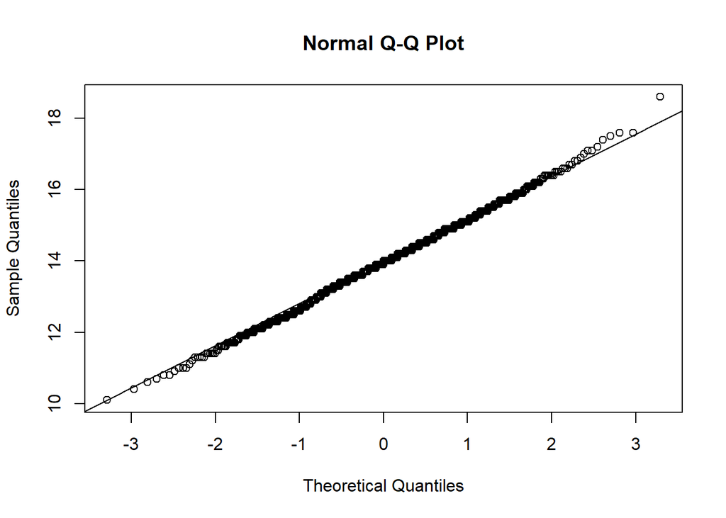

```r
qqnorm(x)
qqline(x)
```

```r
n <- 100
pop_se <- sqrt(lambda/n)  # the estimated SE
pop_se
```

```
## [1] 0.3741657
```

population standard error above

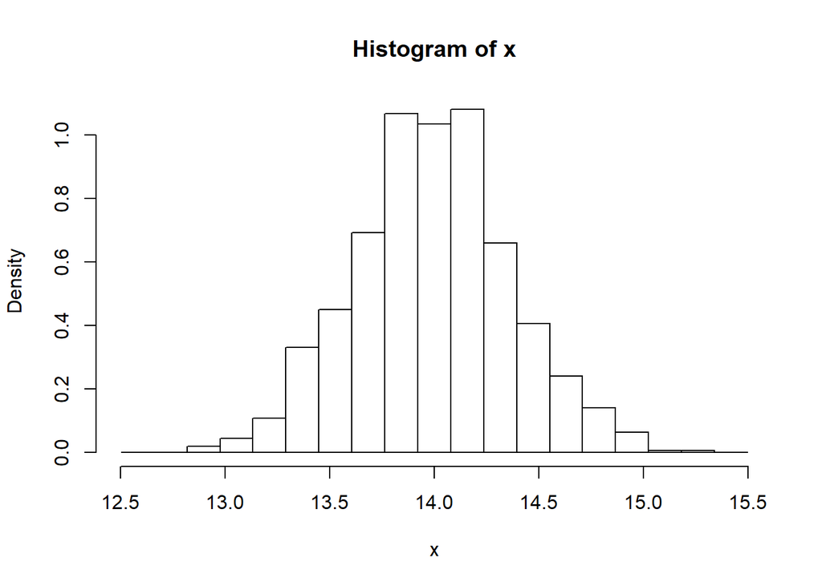

```r
x <- NULL
for (i in 1:1000) {
    x[i] <- mean(rpois(n = n, lambda = lambda))
}
hist(x, breaks = seq(from = lambda - 4 * sqrt(lambda)/sqrt(n), to = lambda +
    4 * sqrt(lambda)/sqrt(n), length.out = 20), probability = TRUE)
```

```r
sd <- sd(x)  # st dev of the sampling distribution
sd
```

```
## [1] 0.3746117
```

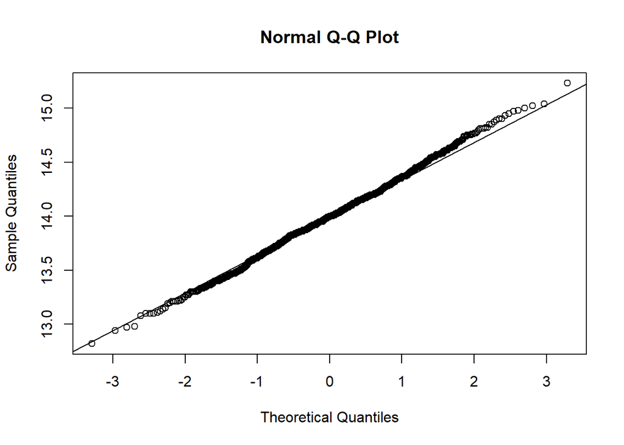

```r
qqnorm(x)
qqline(x)
```

from this qq plot we see that it is normal

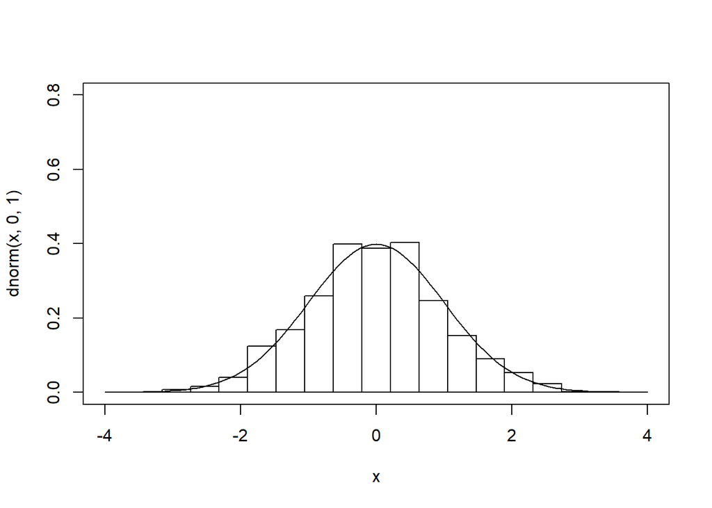

```r
curve(dnorm(x, 0, 1), -4, 4, ylim = c(0, 0.8))
z <- (x - lambda)/pop_se
hist(z, breaks = seq(from = -4, to = 4, length.out = 20), probability = TRUE,
    add = TRUE)
```

we made it normal and trough the CLT

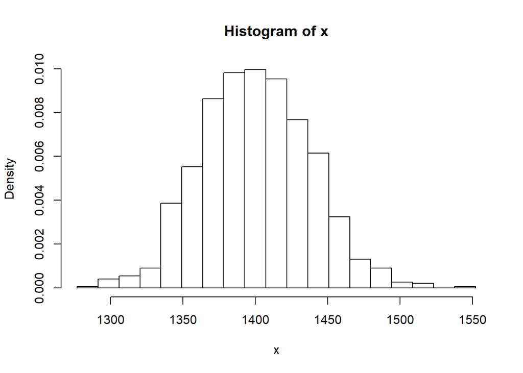

```r
n <- 100
x <- NULL
for (i in 1:1000) {
    x[i] <- sum(rpois(n = n, lambda = lambda))
}
hist(x, breaks = seq(min(x), max(x), length.out = 20), probability = TRUE)
```

here we used the CLT with sum insted of mean

# Confidence Intervals for Sample Proportions

```r
n <- 1000
x <- 856
phat <- x/n  # our estimate of pi
phat
```

```
## [1] 0.856
```

this is our point estimate

```r
n * phat
```

```
## [1] 856
```

```r
n * (1 - phat)
```

```
## [1] 144
```

both above 5 so can continue

```r
pop_se <- sqrt((phat) * (1 - phat)/n)
pop_se
```

```
## [1] 0.01110243
```

this is the poulation se

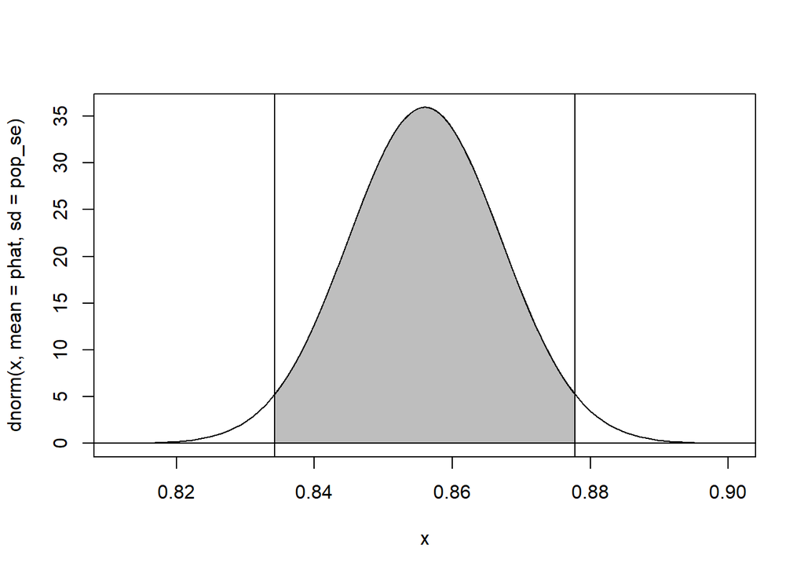

```r
curve(dnorm(x, mean = phat, sd = pop_se), phat - 4 * pop_se, phat + 4 * pop_se)
upper <- phat + qnorm(0.975) * pop_se
lower <- phat - qnorm(0.975) * pop_se
ci <- c(lower, upper)
polygon(cbind(c(ci[1], seq(from = ci[1], to = ci[2], length.out = 1000), ci[2]),
    c(0, dnorm(seq(from = ci[1], to = ci[2], length.out = 1000), mean = phat,
        sd = pop_se), 0)), border = "black", col = "gray")
abline(v = ci)
abline(h = 0)
```

here we constructed a 95% CI and plotted it on a graff #Small Sample Confidence Intervals

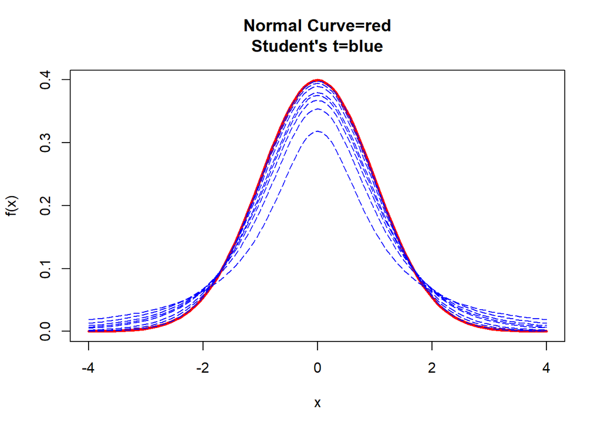

```r
mu <- 0
sigma <- 1
curve(dnorm(x, mu, 1), mu - 4 * sigma, mu + 4 * sigma, main = "Normal Curve=red\nStudent's t=blue",
    xlab = "x", ylab = "f(x)", col = "red", lwd = 3)
for (i in c(1, 2, 3, 4, 5, 10, 20, 100)) {
    curve(dt(x, df = i), mu - 4 * sigma, mu + 4 * sigma, main = "T Curve", xlab = "x",
        ylab = "f(x)", add = TRUE, col = "blue", lty = 5)}
```

```r
n <- 1e+05
mu <- 3.5
sigma <- 4
x <- rnorm(n, mu, sigma)
sample_size <- 30
s <- sample(x, size = sample_size, replace = FALSE)
m <- mean(s)
m
```

```
## [1] 1.937145
```

```r
sd <- sd(s)
sd
```

```
## [1] 4.29364
```

```r
sem <- sd(s)/sqrt(length(s))
sem
```

```
## [1] 0.7839078
```

these are the sd and the se for the t test normal distrabution

```r
lower <- m - qnorm(1 - 0.05/2) * sem  # (1-alpha)/2 each in the upper and lower tails of the distribution
upper <- m + qnorm(1 - 0.05/2) * sem  # (1-alpha)/2 each in the upper and lower tails of the distribution
ci_norm <- c(lower, upper)
ci_norm
```

```
## [1] 0.4007145 3.4735765
```

this is the ci for the normal distrabution

```r
lower <- m - qt(1 - 0.05/2, df = sample_size - 1) * sem  # (1-alpha)/2 each in the upper and lower tails of the distribution
upper <- m + qt(1 - 0.05/2, df = sample_size - 1) * sem  # (1-alpha)/2 each in the upper and lower tails of the distribution
ci_t <- c(lower, upper)
ci_t
```

```
## [1] 0.333874 3.540417
```

this is the CI for the T test

```r
sample_size <- 5
s <- sample(x, size = sample_size, replace = FALSE)
m <- mean(s)
m
```

```
## [1] -0.9209102
```

```r
sd <- sd(s)
sd
```

```
## [1] 2.415688
```

```r
sem <- sd(s)/sqrt(length(s))
sem
```

```
## [1] 1.080329
```

this is the mean, sd and sem when the sample size is 5

```r
lower <- m - qnorm(1 - 0.05/2) * sem  # (1-alpha)/2 each in the upper and lower tails of the distribution
upper <- m + qnorm(1 - 0.05/2) * sem  # (1-alpha)/2 each in the upper and lower tails of the distribution
ci_norm <- c(lower, upper)
ci_norm
```

```
## [1] -3.038315  1.196495
```

this is the CI for the normal distrabutoion (Z test)

```r
lower <- m - qt(1 - 0.05/2, df = sample_size - 1) * sem  # (1-alpha)/2 each in the upper and lower tails of the distribution
upper <- m + qt(1 - 0.05/2, df = sample_size - 1) * sem  # (1-alpha)/2 each in the upper and lower tails of the distribution
ci_t <- c(lower, upper)
ci_t
```

```
## [1] -3.920383  2.078563
```

this this is the CI for the T test when sample size is 5, it is much larger range than the normal distrabution